# B站网红UP主是如何炼成的？

狗熊会

案例背景：“bilibili”是国内知名的视频弹幕网站，类别覆盖鬼畜、游戏、动漫、番剧等数十个品类。B站拥有粉丝近千万的超级网红，网红UP主的视频点击量动辄上百万，同时也存在大量点击量平平的底层UP主。我们希望通过数据分析找到不同UP主之间热度差异的影响因素。更多案例背景介绍，可以参考[B站网红UP主是如何炼成的](https://mp.weixin.qq.com/s/6xu7G4wer7iQ9LDsJhIJhQ)。

数据介绍：案例数据提供了B站8360个UP主的数据观测，共20个变量，其中包括UP主id，粉丝数，性别，发表视频数，发表代表作个数，发表相册数，发表文章数，发表频道数，近期视频平均时长，近期视频平均播放量，关联第三方平台信息，个人标签等。

这个案例的学习目标包括：

1. 了解B站数据；
2. 对文本数据进行简单处理和描述分析；
3. 学习使用ggplot2进行绘图；

## 准备工作

```r
rm(list=ls())                         # 清除工作环境
library(dplyr)                        # 分组汇总
library(reshape2)                     # 数据处理
library(ggplot2)                      # 画图
```

## 任务一

- 找到数据`bilibli_data.csv`，读入样本数据，命名为dat，并用`summary()`函数查看数据记录的变量等情况。
- 根据粉丝数所在区间用`ifelse()`函数定义三种网红程度(red)：大网红（粉丝数>10万）、小网红（粉丝数在2万~10万之间）和小透明（粉丝数在2万以下）。
- 用`summarise()`函数结合`group_by()函数查看各个网红程度的粉丝数、视频数、播放量的均值。

```r
dat = read.csv("bilibli_data.csv")                   # 读取数据
summary(dat)                                         # 查看变量
```

```
##       mid               follower         sex           video
##  Min.   :       75   Min.   :     13   保密:3488   Min.   :   51.0
##  1st Qu.:  3542364   1st Qu.:  10188   女  :1520   1st Qu.:   79.0
##  Median : 17171660   Median :  35670   男  :3352   Median :  131.0
##  Mean   : 74643786   Mean   : 128074               Mean   :  312.9
##  3rd Qu.: 89562128   3rd Qu.: 111209               3rd Qu.:  276.0
##  Max.   :470259211   Max.   :6939197               Max.   :24294.0
##
##      master          album           article            channel
##  Min.   :0.000   Min.   :   0.0   Min.   :   0.000   Min.   : 0.000
##  1st Qu.:1.000   1st Qu.:   4.0   1st Qu.:   0.000   1st Qu.: 0.000
##  Median :3.000   Median :  32.0   Median :   0.000   Median : 2.000
##  Mean   :2.187   Mean   :  93.3   Mean   :   7.895   Mean   : 2.863
##  3rd Qu.:3.000   3rd Qu.: 105.0   3rd Qu.:   2.000   3rd Qu.: 5.000
##  Max.   :4.000   Max.   :4128.0   Max.   :2196.000   Max.   :11.000
##
##    time_ave20         play_ave20          weibo             wx
##  Min.   :    12.0   Min.   :      3   Min.   :0.000   Min.   :0.00000
##  1st Qu.:   273.9   1st Qu.:   3988   1st Qu.:0.000   1st Qu.:0.00000
##  Median :   510.5   Median :  13767   Median :0.000   Median :0.00000
##  Mean   :  1574.9   Mean   :  59624   Mean   :0.225   Mean   :0.09342
##  3rd Qu.:  1024.8   3rd Qu.:  45997   3rd Qu.:0.000   3rd Qu.:0.00000
##  Max.   :146084.2   Max.   :6711586   Max.   :1.000   Max.   :1.00000
##
##        qq             taobao             mail             tiktok
##  Min.   :0.0000   Min.   :0.00000   Min.   :0.00000   Min.   :0.000000
##  1st Qu.:0.0000   1st Qu.:0.00000   1st Qu.:0.00000   1st Qu.:0.000000
##  Median :0.0000   Median :0.00000   Median :0.00000   Median :0.000000
##  Mean   :0.2075   Mean   :0.01639   Mean   :0.04988   Mean   :0.007177
##  3rd Qu.:0.0000   3rd Qu.:0.00000   3rd Qu.:0.00000   3rd Qu.:0.000000
##  Max.   :1.0000   Max.   :1.00000   Max.   :1.00000   Max.   :1.000000
##
##     redbook                self_tags    video_tag_combine video_max_ratio
##  Min.   :0.000000   []          :5666   游戏   :2420      Min.   :0.2283
##  1st Qu.:0.000000   ['鬼畜']    :   8   生活   :1760      1st Qu.:0.7547
##  Median :0.000000   ['MMD']     :   6   动画   : 751      Median :0.9275
##  Mean   :0.002751   ['美妆']    :   5   音乐   : 653      Mean   :0.8497
##  3rd Qu.:0.000000   ['VOCALOID']:   4   科技   : 619      3rd Qu.:0.9870
##  Max.   :1.000000   ['宅舞']    :   4   时尚   : 612      Max.   :1.0000
##                     (Other)     :2667   (Other):1545
```

```r
dat$red = ifelse(dat$follower >100000,"大网红", ifelse(dat$follower <20000,"小透明","小网红")) # 定义网红程度
dat$red = factor(dat$red, levels = c("小透明","小网红","大网红"))  # 重新排序网红程度
summarise(group_by(dat, red), 粉丝数 = mean(follower),
          视频数 = mean(video), 播放量 = mean(play_ave20))         # 查看分组各数值的均值
```

```
## # A tibble: 3 x 4
##   red     粉丝数 视频数  播放量
##   <fct>    <dbl>  <dbl>   <dbl>
## 1 小透明   7706.   210.   9663.
## 2 小网红  49860.   325.  29702.
## 3 大网红 396362    439. 167700.
```

## 任务二

用`summarise()`函数结合`group_by()`函数计算各品类不同网红程度的UP主人数。绘制不同视频品类(video_tag_combine)的网红程度分布图（按UP主人数从多到少排序），并进行简要解读。观察哪些品类网红较多，哪些品类分布较为均衡。

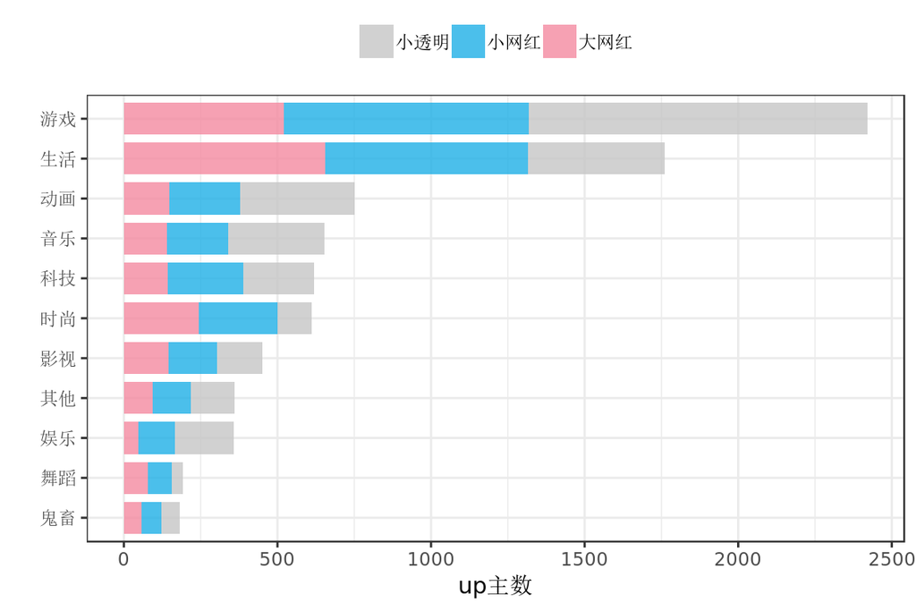

```r
draw = summarise(group_by(dat,video_tag_combine, red),n = n())# 分品类计算不同网红程度UP主数
tag_sort = names(sort(table(dat$video_tag_combine)))
draw$video_tag_combine = factor(draw$video_tag_combine,levels = tag_sort) # 按照UP主数重新排序
draw$red = factor(draw$red,levels = c("小透明","小网红","大网红"))        # 按网红程度重新排序
ggplot(draw, aes(x = video_tag_combine, y = n, fill = red))+  # 堆叠直方图
  geom_bar(stat = "identity", alpha = 0.8, width = 0.8)+
  scale_fill_manual(values=c("#c5c5c5","#1fafe6","#f48aa0"))+ # 更改颜色
  xlab("")+ ylab("up主数")+
  coord_flip()+                                               # 坐标轴翻转
  theme_bw() + theme(legend.title = element_blank(),
                     legend.position = "top")                 # 在上方添加图例，并去掉图例的标题
```

## 任务三

将近期视频时长(time_ave20)的单位转为分钟，并用`ifelse()`函数划分时长区间(time_group)：0至5分钟，5至15分钟，15至30分钟，30至60分钟，60分钟以上。分组计算人数和占比后，绘制不同时长各网红程度的人数占比分布图，并进行简要解读。

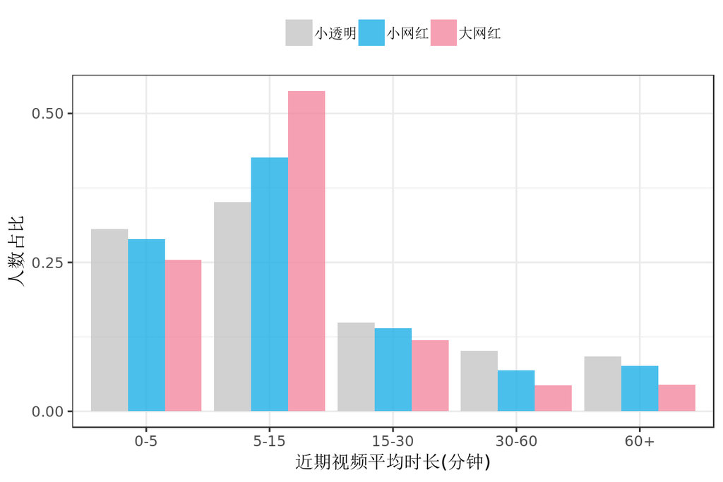

```r
dat$time_ave20 = dat$time_ave20/60                          # 将时长转为分钟
dat$time_group = ifelse(dat$time_ave20 <5, "0-5",           # 划分时长区间
                    ifelse(dat$time_ave20 <15,"5-15",
                           ifelse(dat$time_ave20 <30,"15-30",
                                  ifelse(dat$time_ave20 <60,"30-60","60+"))))
# 重新排序时长区间
dat$time_group = factor(dat$time_group,levels = c("0-5","5-15","15-30","30-60","60+"))
draw = summarise(group_by(dat, red, time_group),n = n())     # 分区间计算不同网红程度UP主数
draw$all_n = rep(table(dat$red),each = 5)                    # 计算各网红程度的UP主总数
draw$ratio = draw$n / draw$all_n                             # 计算不同网红程度的各区间占比
ggplot(data = draw,aes(x = time_group, y = ratio, fill = red)) +    # 非堆叠直方图
  geom_bar(stat = "identity", alpha = 0.8, position = "dodge")+
  scale_fill_manual(values = c("#c5c5c5","#1fafe6","#f48aa0"))+
  scale_y_continuous(breaks = seq(0,0.6,0.25))+              # 调整Y轴分隔
  xlab("近期视频平均时长(分钟)") + ylab("人数占比")+
  theme_bw() + theme(legend.title = element_blank(),
                     legend.position = "top")                # 在上方添加图例，并去掉图例的标题
```

解读：对视频时间，如果以15分钟作为分界线把UP主分为“短视频类”和“长视频类”，可以明显发现B站UP主们以“短视频类”居多。并且对“长视频类”UP主，可以看到大网红的比例相较短视频要明显更低。在B站上如果发布视频时间较长，恐怕会令观众“望而却步”，难以在众多UP主的竞争中得到关注，并且成长为大网红的难度也更大。反过来聚焦短视频为主的UP主们，可以发现超过50%的大网红近期视频平均时长在5~15分钟内，这也可以为新人UP主提供一个参考：视频的时间最好控制在这个区间，在B站获得关注的可能更大。

## 任务四

- 针对个人主页上发表相册(album)、频道(channel)、文章(article)的三种行为，首先计算各网红程度的UP主有过上述行为的人数占比。提示：先用`ifelse()`函数定义是否有上述三种行为（变量名：album_group、channel_group、article_group），再用`summarise()`函数加`groupby()`及`mean()`函数对上述三个变量求分组均值即为人数占比。
- 其次针对有上述行为的UP主，绘制三种行为发表量的分组箱线图，对比不同网红程度UP主在上述行为的差异。提示：绘图时将“宽数据”转为需要的“窄数据”可使用reshape2包的`melt()`函数

```r
dat$album_group   = ifelse(dat$album   >0, 1, 0)        # 是否发表过相册
dat$channel_group = ifelse(dat$channel >0, 1, 0)        # 是否发表过频道
dat$article_group = ifelse(dat$article >0, 1, 0)        # 是否发表过文章
summarise_all(group_by(dat[,c("red","album_group",      # 各网红程度有上述发表行为的占比
                              "channel_group","article_group")], red), mean)
```

```
## # A tibble: 3 x 4
##   red    album_group channel_group article_group
##   <fct>        <dbl>         <dbl>         <dbl>
## 1 小透明       0.771         0.578         0.368
## 2 小网红       0.871         0.655         0.388
## 3 大网红       0.928         0.697         0.364
```

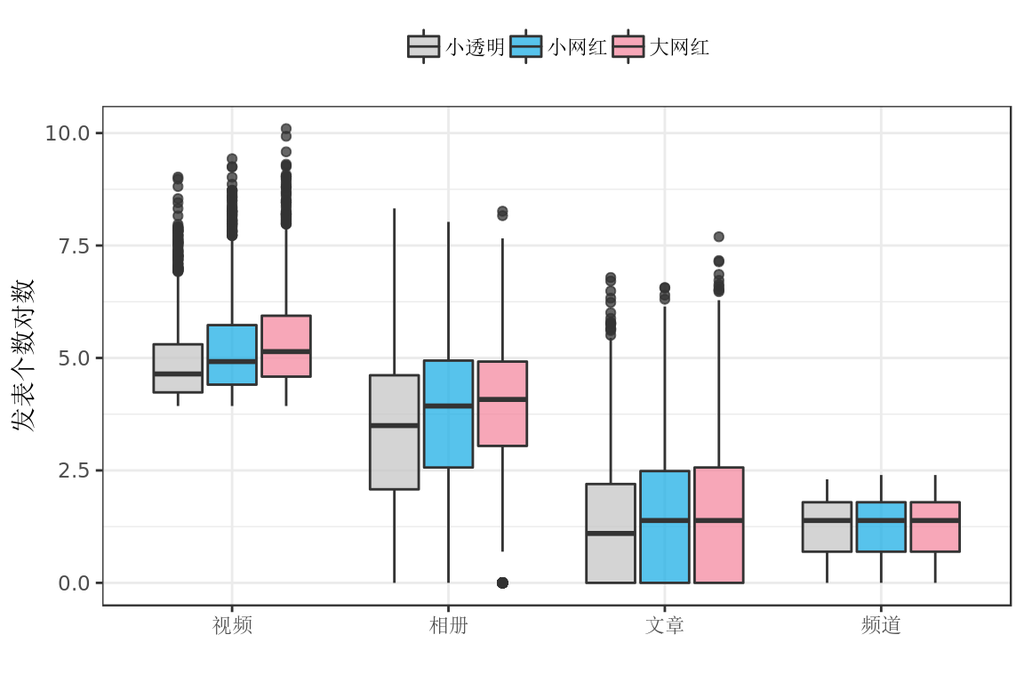

```r
draw = dplyr::select(dat, "red","video","album",
                   "article","channel")                 # 提取上述行为有关变量
colnames(draw) = c("red","视频","相册",
                   "文章","频道")                       # 重新用中文命名行为
draw = melt(draw)                                       # 转为画图可用数据
ggplot(data = draw,aes(x = variable, y = log(value), fill = red)) + # 分组箱线图，Y转为对数
  geom_boxplot(alpha = 0.75)+
  xlab("") + ylab("发表个数对数")+
  scale_fill_manual(values=c("#c5c5c5","#1fafe6","#f48aa0"))+
  theme_bw() + theme(legend.title = element_blank(),
                     legend.position = "top")           # 在上方添加图例，并去掉图例的标题
```

解读：对于UP主的行为特征，通过分析发现，大网红发布视频、相册数目均多于小网红和小透明，相册一方面可能是与视频相关的宣传图、截图、攻略，帮助粉丝快速get到重点内容，吸引眼球，又或者是UP主日程生活中的一些照片，可拉进与粉丝之间的距离。同时，有更多的大网红设置频道来管理视频，可以使得视频更加有条理，既能让观众用户体验更好，又能显示出UP主的“专业范儿”。但在文章发布方面，三个类型的UP主没有明显差别，这可能是由于B站主要还是靠原创视频来吸引注意，目前文章板块整体得到的关注仍然较小。

## 任务五

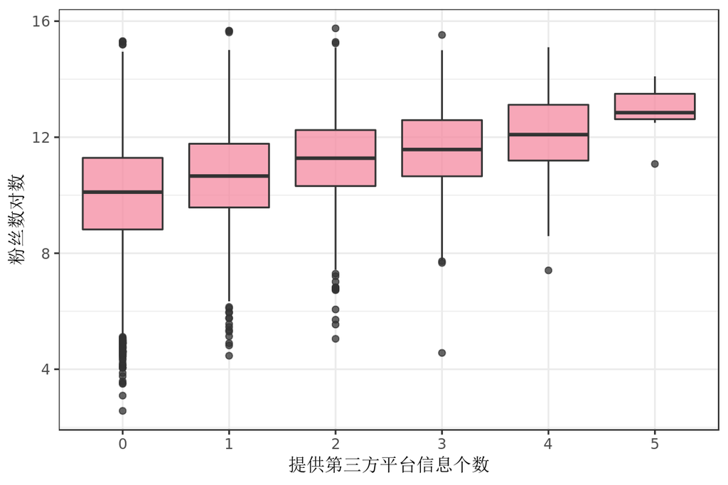

```r
dat$third = dat$weibo + dat$wx + dat$qq +
  dat$taobao + dat$mail + dat$tiktok + dat$redbook            # 计算关联第三方平台个数

ggplot(data = dat,
       aes(x = as.character(third), y = log(follower))) + # 箱线图
  geom_boxplot(alpha = 0.75, fill = "#f48aa0")+
  xlab("提供第三方平台信息个数") + ylab("粉丝数对数")+
  theme_bw() + theme(legend.position = "none")            # 去掉图例
```

```r
names = c('red','video_tag_combine',
          "weibo", "qq", "wx", "mail",
          "taobao", "redbook", "tiktok")        # 提取有关变量名
third_dat = summarise_all(
             group_by(dat[,names], red,
                video_tag_combine), sum)        # 分品类、网红程度计算关联各第三方平台的人数
third_dat = subset(third_dat, red =='大网红')   # 筛选大网红的数据
colnames(third_dat)[2:9] =  c('品类','微博','QQ','微信','邮箱','淘宝',
                              '小红书','抖音')  # 用中文重命名
third_dat$n = table(dat[which(dat$red =='大网红'),
                        "video_tag_combine"])   # 计算各品类UP主总数
third_dat[,3:9] = round(third_dat[,3:9] / third_dat$n, 2)# 计算各品类关联各第三方平台的人数占比
third_dat[which(third_dat$品类 != "其他"),]
```

```
## # A tibble: 10 x 10
## # Groups:   red [1]
##    red    品类   微博    QQ  微信  邮箱  淘宝 小红书  抖音 n
##    <fct>  <fct> <dbl> <dbl> <dbl> <dbl> <dbl>  <dbl> <dbl> <table>
##  1 大网红 动画   0.31 0.39   0.07  0.09  0.03   0     0.02 147
##  2 大网红 娱乐   0.28 0.2    0.11  0.02  0      0     0     46
##  3 大网红 影视   0.39 0.290  0.4   0.11  0      0     0.01 146
##  4 大网红 时尚   0.37 0.05   0.17  0.12  0.05   0.04  0.01 243
##  5 大网红 游戏   0.41 0.37   0.08  0.12  0.02   0     0.01 522
##  6 大网红 生活   0.32 0.2    0.19  0.1   0.04   0     0.01 655
##  7 大网红 科技   0.27 0.22   0.34  0.08  0.06   0     0.01 143
##  8 大网红 舞蹈   0.45 0.41   0.08  0.01  0.01   0     0.01  78
##  9 大网红 音乐   0.37 0.34   0.12  0.07  0.03   0     0.02 139
## 10 大网红 鬼畜   0.5  0.45   0.07  0.1   0      0     0     58
```

解读：与第三方平台关联越多，UP主自我宣传、曝光的渠道就越多，越有可能从各方平台吸收粉丝。在各个第三方平台中，关联微博是大部分UP主的首选。微博作为国内在线社交媒体的头部平台，用户量大、用户活跃度高、信息传播速度快，的确是UP主吸粉的优质渠道。同时，通过考察微博之外的其他关联平台，可以发现不同品类的UP主存在不同的侧重，如：动画、舞蹈、鬼畜和游戏等娱乐类UP主更多使用QQ；生活、影视、科技和时尚这种偏日常生活类的更多考虑微信；而时尚、科技类有带货需求的则有更多UP主关联了小红书和淘宝为变现做好准备。